# STA 101 - HW 1

Mingyi Xue

April 5, 2018

### Load databases into current workingspace:

```
##   InfctRsk MedSchool Stay
## 1      4.1        No 7.13
## 2      1.6        No 8.82
## 3      2.7        No 8.34
```

```
##   Location PovPct Brth15to17
## 1  Alabama   20.1       31.5
## 2   Alaska    7.1       18.9
## 3  Arizona   16.1       35.0
```

```
##   days  fitness
## 1   23 BelowAve
## 2   25 BelowAve
## 3   21 BelowAve
```

### Load package `ggplot2`:

```r
library(ggplot2)
```

### Problem 1

**(a)**

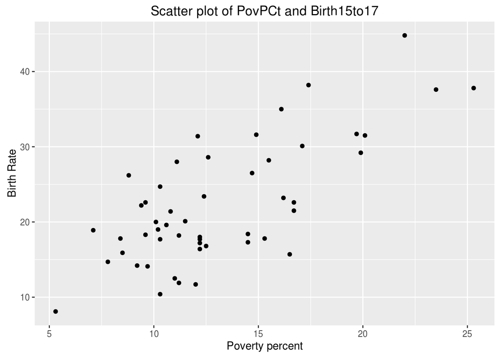

The plot suggests a linear relationship between PovPct and Brth15to17.

**(b)**

The estimated correlation between PovPct and Brth15to17 is 0.7303 and this suggests a strong linear relationship.

**(c)**

```
## [1]  5.30 10.25 12.20 15.80 25.30
```

minimun:5.3  
the first quartile:10.25  
median:12.2  
the third quartile:15.8  
maximum:25.3

**(d)**

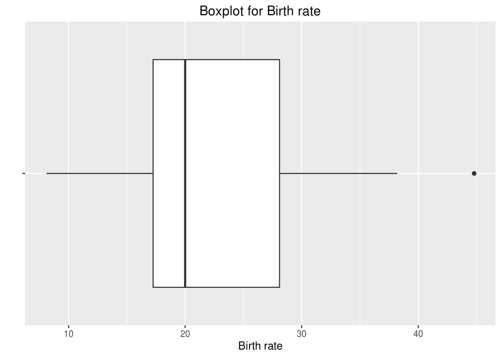

The default criteria to set outliers in R is:  
upper_boundary=the third quartile + (the third quartile - the first quartile) * 1.5  
lower_boundary=the first quartile - (the third quartile - the first quartile) * 1.5  
According to the boxplot of Brth15to17, there is an exremely large value outlier.

**(e)**

Use the formula:  
the.left_boundary = mean - 3 * sd  
the.right_boundary = mean + 3 * sd  
An appropriate range for PovPct is from 0.286 to 25.9493.

### Problem 2

**(a)**

```
## (Intercept)      PovPct
##      4.2673      1.3733
```

The estimated linear regression line of Brth15to17 by PovPct is  
$\hat{y}=4.2673+ 1.3733X_{1}$

**(b)**

The estimated slope is $\hat{\beta_{1}} = 1.3733$. It means when the percent of the states population living in poverty increases by 1 percent, the estimated value of birth rate per 1000 females 15 to 17 years old will increase by 1.3733 percent on average.

**(c)**

The estimated intercept is $\hat{\beta_{0}} = 4.2673$. It is inapproriate because a state cannot be absolutely poverty-free in reality.

**(d)**

The estimated average value of Brth15to17 is 18.0003 at PovPct equals 10.

**(e)**

The value of $R^{2}$ is 0.533.  
It means if we use linear regression model to estimate the value of Brth15to17 instead of the average value, the total error can be reduced by $53.3\%$.

### Problem 3

**(a)**

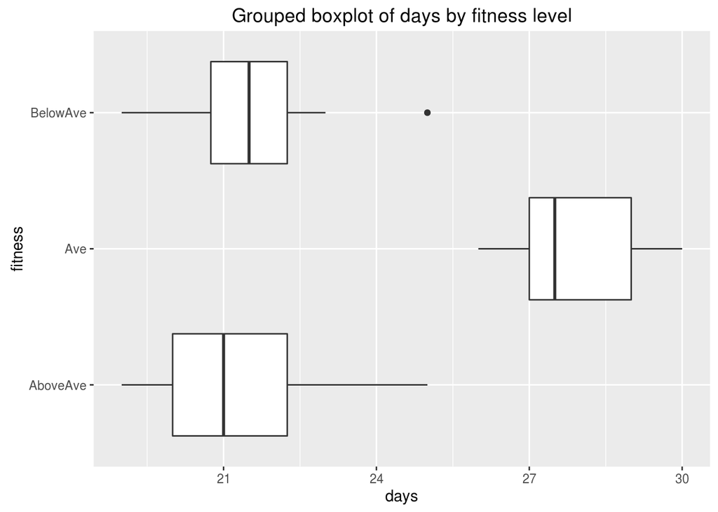

**(b)**

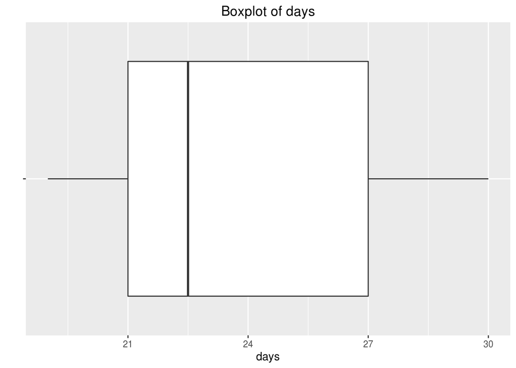

No outliers in $days$.

**(c)**

Corresponding $X_{i}$’s are X_Ave and X_Bel.

**(d)**

minimun:19  
the first quartile:21  
median:22.5  
the third quartile:27  
maximum:30

**(e)**

Yes. Although $days$ have no outliers in its boxplot as a whole, there are outliers when categorized by $fitness$.

### Problem 4

**(a)**

```r
unique(rehab$fitness)
```

```
## [1] BelowAve Ave      AboveAve
## Levels: AboveAve Ave BelowAve
```

$\hat{y} = 21.4167 + 6.3333X_{Ave} + 0.0833X_{Bel}$

**(b)**

$\hat{\beta}_{1}$ means the estimated average value of number of days that people in category Ave need to complete the therapy is 6.3333 more than people in category AboveAve.

**(c)**

$\hat{\beta}_{2}$ means the estimated average value of number of days that people in category BelowAve need to complete the therapy is 0.0833 more than people in category AboveAve.

**(d)**

$\hat{\beta}_{0}$ means the estimated average value of number of days that people in category AboveAve need to complete the therapy is 21.4167.

**(e)**

category fitness=AboveAve:$\hat{y}=21.4167$  
category fitness=Ave:$\hat{y}=27.75$  
category fitness=BelowAve:$\hat{y}=21.5$

### Problem 5

**(a)**

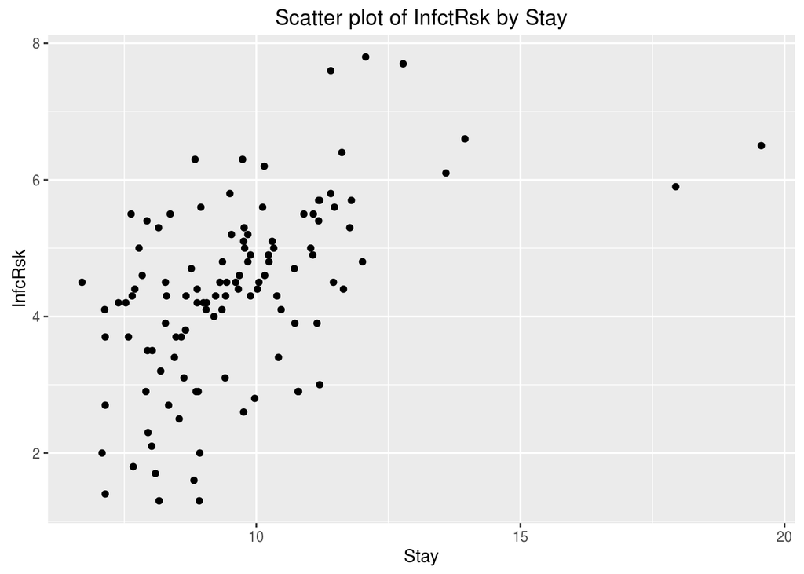

There are several outliers on hospital dataset. Correlation between InfctRsk and Stay is 0.5334, which indicates a medium linear relationship between this two random variables.

**(b)**

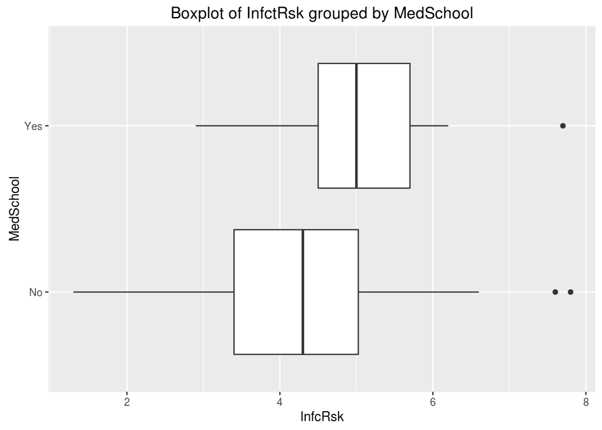

There is no apparent difference between different categories of InfctRsk because two boxplots overlap a lot.

**(c)**

The correlation between InfctRsk and Stay is 0.5334. MedSchool is not a numeric variable.

**(d)**

Yes. There are outliers on the boxplot of InfctRsk grouped by MedSchool.

**(e)**

A reasonable range of average patient stay is from 3.914 to 15.383.

### Problem 6

**(a)**

```
##
## Call:
## lm(formula = InfctRsk ~ ., data = hospital)
##
## Coefficients:
##  (Intercept)  MedSchoolYes          Stay
##       0.8628        0.3056        0.3572
```

The regression equation is: $\hat{y} = 0.8628 + 0.3056X_{Yes}+ 0.3572X_1$.

**(b)**

hospitals not in a teaching school: $\hat{y} = 0.8628 + 0.3572X_1$  
hospitals in a teaching school:$\hat{y} = 1.1684 + 0.3572X_1$

**(c)**

$\hat{\beta}_{1}$ means the percentage of patients who get a secondary infection during their hospital stay will be 0.3056 lager if they are in teaching school associated with the hospital than those who are not.

**(d)**

$\hat{\beta}_{2}$ means the percentage of patients who get a secondary infection during their hospital stay will increase by 0.3572 on average if the average length of their stay increase by 1 day.

**(e)**

The estimated value of infection percentage is 3.363 on average.

### Problem 7

**(a)**

```
##
## Call:
## lm(formula = InfctRsk ~ MedSchool + Stay + MedSchool * Stay,
##     data = hospital)
##
## Coefficients:
##       (Intercept)       MedSchoolYes               Stay
##            0.6368             1.7132             0.3812
## MedSchoolYes:Stay
##           -0.1315
```

**(b)**

**(c)**

**(d)**

**(e)**

The estimated value is 3.3051 on average at MedSchool=“No” and Stay=7.

### Problem 8

**(a)**

False. Correlation only measures the strength of linear relationship.

**(b)**

False. A regression model with interation terms can be presented as $\hat{y}=\hat{\beta}_{0}+\hat{\beta}_{1}X_{1}+\hat{\beta}_{2}X_{2}+\hat{\beta}_{3}X_{1}X_{2}$, it is the same with the model of non-interaction terms if and only if $\hat{\beta}_{3}=0$, which scarcely happens.

**(c)**

True. $r$ range from $-1$ to $1$.  
If $r>0$ and $r<=1$, this suggests a positive linear relationship. Else if $r<0$ and $r>=-1$,this suggests a negative linear relationship. Else if $r=0$, this suggests no linear relationship.

**(d)**

True. $e_{i} = y_{i} - \hat{y}_{i}$ when $e_{i} > 0$, it means $y_{i} > \hat{y}_{i}$, which indicates that we underestimated the value.

### R Appendix

```r
hospital <- read.csv("~/STA 101/Homework/HW1/hospital.csv", header = TRUE)
head(hospital, n=3)
poverty <- read.csv("~/STA 101/Homework/HW1/poverty.csv", header = TRUE)
head(poverty, n=3)
rehab <- read.csv("~/STA 101/Homework/HW1/rehab.csv", header = TRUE)
head(rehab, n=3)
library(ggplot2)
qplot(PovPct, Brth15to17,data = poverty)+
  ggtitle("Scatter plot of PovPCt and Birth15to17")+
  xlab("Poverty percent")+
  ylab("Birth Rate")
the.correlation = round(cor(poverty$Brth15to17, poverty$PovPct),4)
the.five = fivenum(poverty$PovPct)
the.five
ggplot(poverty,aes(y = Brth15to17,x = factor("")))+
  geom_boxplot()+
  ggtitle("Boxplot for Birth rate")+
  ylab("Birth rate")+
  xlab("")+
  coord_flip()
the.mean = mean(poverty$PovPct)
the.sd = sd(poverty$PovPct)
the.left_boundary = round(the.mean - 3 * the.sd, 4)
the.right_boundary = round(the.mean + 3 * the.sd, 4)
the.line = lm(Brth15to17~PovPct, data = poverty)
the.coef = round(the.line$coefficients,4)
the.coef


y_i = the.coef[1] + the.coef[2] * 10
the.summary = summary(the.line)
ggplot(rehab, aes(x = fitness, y = days))+
  geom_boxplot()+
  xlab("fitness")+
  ylab("days")+
  ggtitle("Grouped boxplot of days by fitness level")+
  coord_flip()
ggplot(rehab, aes(x = factor(""), y = days))+
  geom_boxplot()+
  xlab("")+
  ylab("days")+
  ggtitle("Boxplot of days")+
  coord_flip()

the.five = fivenum(rehab$days)

the.line=lm(days ~ fitness, data = rehab)
the.coef = round(the.line$coefficients,4)
unique(rehab$fitness)




qplot(Stay, InfctRsk, data = hospital)+
  ggtitle("Scatter plot of InfctRsk by Stay")+
  xlab("Stay")+
  ylab("InfcRsk")

the.correlation1 = round(cor(hospital$InfctRsk, hospital$Stay),4)
ggplot(hospital, aes(x = MedSchool, y = InfctRsk))+geom_boxplot()+
  ggtitle("Boxplot of InfctRsk grouped by MedSchool")+
  xlab("MedSchool")+
  ylab("InfcRsk")+
  coord_flip()
the.correlation1 = cor(hospital$InfctRsk, hospital$Stay)

the.mean=mean(hospital$Stay)
the.sd=sd(hospital$Stay)
the.line=lm(InfctRsk ~ ., data = hospital)
the.coef = round(the.line$coefficients,4)
the.line
the.temp=the.coef[1] + the.coef[2]


x.star =data.frame(Stay=7, MedSchool= "No")
the.result=predict(the.line, x.star)
the.line=lm(InfctRsk~MedSchool+Stay+MedSchool*Stay, data=hospital)
the.coef=round(the.line$coefficients, 4)
the.line




x.star=data.frame(MedSchool="No",Stay=7)
y_i=round(predict(the.line, x.star),4)
```